# Table 1 de-novo

Table 1of ML’s paper has a list of mutations found in phage-treated chemostats. mutations are aggregated by genes and parse between N- and P- limitations

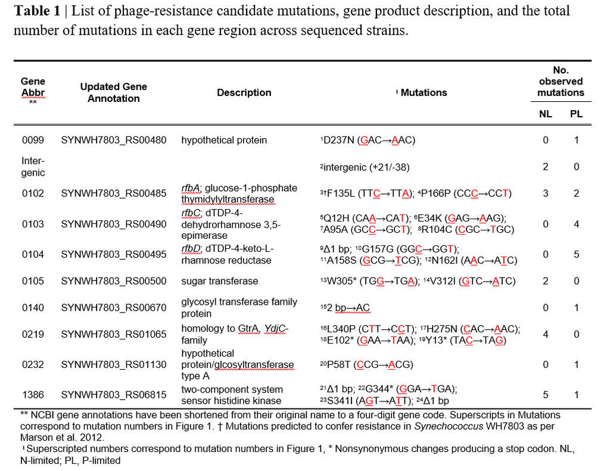

Table 1 by ML

I have found a mistake in parsing the mutation data for testing the genetic-phenotypic correlation. I want to see if that mistake was local to that analysis or more general. I will try and independently derive the summary in table 1 from the data available on MLs repo.  
I will import the data explored in *exploring the data.Rmd*.

```r
rm(list=ls())
library(tidyverse, quietly = TRUE)
library(cowplot, quietly = TRUE)
# table of strains and their source (time, treatment)
strains <- read_csv("../data/strains.csv")
# remove ansector
strains <- filter(strains,strain_ID!="WH7803")
rbind(head(strains,n=3), rep("...",ncol(strains)),tail(strains,n=3))
```

| trt | lim | cID | time | strain_ID |
| --- | --- | --- | --- | --- |
| Ph- | N | N2 | 1 | 01N2S3 |
| Ph- | N | N3 | 1 | 01N3S3 |
| Ph- | N | N5 | 1 | 01N5S4 |
| ... | ... | ... | ... | ... |
| Ph+ | P | P5 | 21 | 21P5S1 |
| Ph+ | N | N3 | 5 | 05N3S3 |
| Ph+ | P | P5 | 5 | 05P5S4 |

```r
# data on mutations found in each strain. Requires processing
breseq <- read_csv("../data/breseq.compare.csv")#,na = "?")
rbind(head(breseq,n=3), rep("...",ncol(breseq)),tail(breseq,n=3))
```

| Predicted mutations | X2 | X3 | X4 | X5 | X6 | X7 | X8 | X9 | X10 | X11 | X12 | X13 | X14 | X15 | X16 | X17 | X18 | X19 | X20 | X21 | X22 | X23 | X24 | X25 | X26 | X27 | X28 | X29 | X30 | … |
| --- | --- | --- | --- | --- | --- | --- | --- | --- | --- | --- | --- | --- | --- | --- | --- | --- | --- | --- | --- | --- | --- | --- | --- | --- | --- | --- | --- | --- | --- | --- |
| position | mutation | 01N2S3.g | 01N3S3.g | 01N5S4.g | 01P3S1.g | 01P4S5.g | 01P5S1.g | 03N1S1.g | 03N2S5.g | 03N3S2.g | 03N3S4.g | 03N5S2.g | 03P2S4.g | 03P3S5.g | 03P5S5.g | 05N2S5.g | 05N3S3.g | 05P2S1.g | 05P2S2.g | 05P3S1.g | 05P4S4.g | 05P5S4.g | 12P2S5.g | 12P3S4.g | 12P4S2.g | 16N5S4.g | 16P3S2.g | 16P5S2.g | 19N3S4.g | … |
| 1 | ?2,366,975bp | NA | NA | NA | NA | NA | NA | 100% | NA | NA | NA | NA | NA | NA | NA | NA | NA | NA | NA | NA | NA | NA | NA | NA | NA | NA | NA | NA | NA | … |
| 12,864 | C?G | NA | NA | NA | NA | NA | NA | NA | NA | NA | NA | NA | NA | NA | NA | NA | NA | NA | NA | NA | NA | NA | NA | NA | NA | NA | NA | NA | NA | … |
| ... | ... | ... | ... | ... | ... | ... | ... | ... | ... | ... | ... | ... | ... | ... | ... | ... | ... | ... | ... | ... | ... | ... | ... | ... | ... | ... | ... | ... | ... | … |
| 2,176,220 | G?A | NA | 100% | NA | NA | NA | NA | NA | NA | NA | NA | NA | 100% | NA | NA | NA | NA | NA | NA | NA | NA | NA | NA | NA | NA | NA | NA | NA | 100% | … |
| 2,176,310 | G?A | NA | NA | NA | NA | 100% | 100% | NA | NA | 100% | NA | NA | NA | NA | 100% | NA | 100% | NA | NA | 100% | NA | NA | NA | 100% | NA | 100% | NA | NA | NA | … |
| 2,233,661 | +A | 100% | 100% | 100% | 100% | 100% | 100% | NA | 100% | 100% | 100% | 100% | 100% | 100% | 100% | 100% | 100% | 100% | 100% | 100% | 100% | 100% | 100% | 100% | 100% | 100% | 100% | 100% | 100% | … |

Processing breseq data to a strain X locus matrix

```r
# make strain names be column names
colnames (breseq)<- gsub(".g","",breseq[1,])
# Remove unnecessary rows

breseq <-
breseq %>%
  filter(position!="position")%>%
  mutate(position=as.numeric(gsub(",","",position)))


# there are some duplicated posotions. that will be a problem later
while(sum(duplicated(breseq$position))){
  breseq$position[duplicated(breseq$position)] <- breseq$position[duplicated(breseq$position)]+0.1
}

# crop out the annotation data
breseq.annot  <-
  breseq%>%
    select(position,mutation,annotation,gene,description)
breseq  <-  breseq[,-c(2,39,40,41)] #columns with annotations

# Making the mutation presence/absence dat numeric

for(i in seq(nrow(breseq))){

  # empty cell (no mutation) transformed to 0
   breseq[i,as.vector(is.na(breseq[i,]))] <-0

  # Predicted mutation transformed from '100%' to 1
   breseq[i,as.vector(breseq[i,]=="100%")] <-1
  # Question mark ("?") transformed to NA suggesting that there isn't enough information to predict a mutation
   breseq[i,as.vector(breseq[i,]=="?")] <-NA
}
# Transpose matrix to have positions in columsn and strains in rows
breseq <- t(breseq)
#fix the transposition repercussions
colnames(breseq) <- breseq[1,]
breseq <- breseq[-1,]
class(breseq) <- "numeric"
```

Clening and adding the strain metadata to the table

```r
d <- as.data.frame(breseq)
#remove posioition 1 as that is a false poisitive
  # the breseq file lists that the whole genome is missing
d <- d[,-1]
loci <- colnames(d)
# any positions withput mutations?
sum(apply(d, 2, sum,na.rm = T)==FALSE) #0
```

```
[1] 0
```

```r
# any strains without any mutation?
sum(apply(d, 1, sum,na.rm = T)==FALSE)
```

```
[1] 1
```

```r
#1,  the strain that had a "whole genome deletion"
del.strain <- which(apply(d, 1, sum,na.rm = T)==FALSE)
# I will leave it to facilitate joining tables below

d$strain_ID <- row.names(d)
#testing that all strain IDs match between the 2 tables
sum(d$strain_ID%in% strains$strain_ID)+
sum(strains$strain_ID%in% d$strain_ID)==
  length(strains$strain_ID)+length(d$strain_ID)
```

```
[1] TRUE
```

```r
# add meta data
d <- inner_join(d, strains)
# remove no mutation strain
d <- d[d$strain_ID!=names(del.strain),]
```

##Summarize by phage treatment and nutrient limitation

[figure not shown]

##summarizing loci by genes

```r
d.annot <-
d.sum%>%
select(-"sum.mut")%>%
  gather(key = "position",value = "n.mut",loci)
d.annot$position <- as.numeric(d.annot$position)


#reverse the de-duplication from above
#need to remove te decimal addition that was use to make poistion names unique
d.annot$position <- floor(d.annot$position)
breseq.annot$position <- floor(breseq.annot$position)

#Remove the false postive position (whole genome deletion)
breseq.annot <- filter(breseq.annot, position>1)
#Check that position columan matches
sum(!(breseq.annot$position %in% d.annot$position))
```

```
[1] 0
```

```r
sum(!(d.annot$position %in% breseq.annot$position))
```

```
[1] 0
```

```r
# they do!!

d.annot <-
breseq.annot %>%
  slice(rep(1:n(), each = 4))%>%
  bind_cols(d.annot,.)
# check that binding is ok
sum(!(d.annot$position==d.annot$position1))
```

```
[1] 0
```

```r
d.sum.annot <-
  d.annot%>%
      group_by(trt,lim,gene,description)%>%
  summarise_at("n.mut", sum, na.rm=TRUE)%>%
  filter(n.mut>0)
```

## filter out mutations found in both phage + and - **AND** Spread by limiting nutrient

[output not shown]

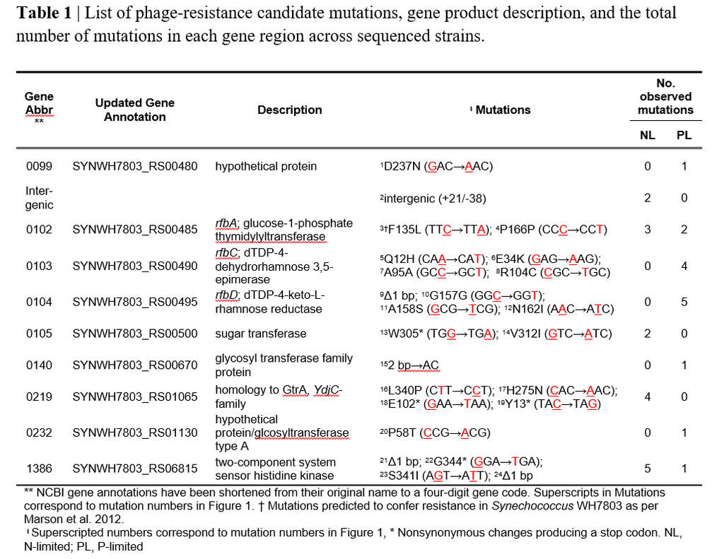

Table 1 by ML

### **The tables don’t match!!**

Mostly there are genes in my table that don’t appear in ML’s table 1.  
> Look into psbA: Why are there 25 mutations there (perhaps due to sequence variant form phage?)  
> Some mutation are in utergenic regions. Possibly 101/102 is an example?